# Homework 1

```r
#install.packages("TeachingDemos")
#install.packages("plyr")
#install.packages("dplyr")
#install.packages("readr")
#install.packages("ggplot2")
#install.packages("stringr")
#install.packages("lubridate")
#install.packages("tidyr")
#install.packages("magrittr")
library(TeachingDemos)
library(plyr)
library(dplyr)
library(readr)
library(ggplot2)
library(stringr)
library(lubridate)
library(tidyr)
library(magrittr)


rod.inspection = read_csv("/users/charlie/downloads/HW1/Rodent_Inspection.csv")

my_name = "Hongbing Luo"

set.seed(char2seed(my_name))
rod.inspection = sample_frac(rod.inspection, .8)
rod.inspection = rod.inspection[, sample(1:ncol(rod.inspection))]
```

# PART I. Descriptive Statistics and Figures

### a. Rat Sightings Change in the Five Boroughs of NYC

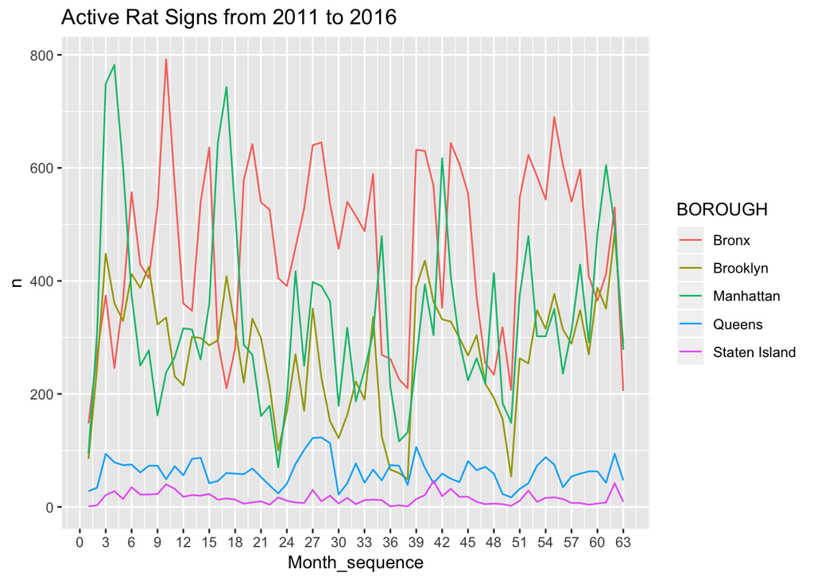

```r
rod.inspection$Year <- year(mdy_hms(rod.inspection$INSPECTION_DATE))
rod.inspection$Month <- month(mdy_hms(rod.inspection$INSPECTION_DATE))

month <- month(mdy_hms(rod.inspection$INSPECTION_DATE))
year <- year(mdy_hms(rod.inspection$INSPECTION_DATE))
active_date <- data.frame(year, month)
# put months into a sequence of numbers from 1 to 63
active_date$sequence <- (year-2011) * 12 + month
rod.inspection$Month_sequence <- active_date$sequence

# The months selected are from Jan. 2011 to Mar. 2016, that is 63 months in total.
rod.inspection %>% group_by(Month_sequence, BOROUGH) %>% filter(Year > 2010, RESULT == "Active Rat Signs") %>% tally() %>% ggplot(aes(x = Month_sequence, y = n, col = BOROUGH)) + geom_line() + labs(title = "Active Rat Signs from 2011 to 2016") + scale_x_continuous(breaks = seq(0, 63, 3))
```

### b. Sightings Over the Years

The rat problem stayed relatively steady for Staten Island and Queens over the last five years. For the other three boroughs, the signs fluctuated over the years. Bronx has often been the most problematic borough of all. Though fluctuated, it often had more active signs than the other regions.

### c. Seasonality

There are seasonal trends in rat sightings, and vary from boroughs. For Manhattan, rat problems are the most severe during springs (April). Moreover, it has become more fluctuated recently. Brooklyn’s pattern is similar to Manhattan’s. Bronx usually has more rat sightings during summers and falls. Queens and Staten Island stay relatively steady over the years.

### d. Efficiency

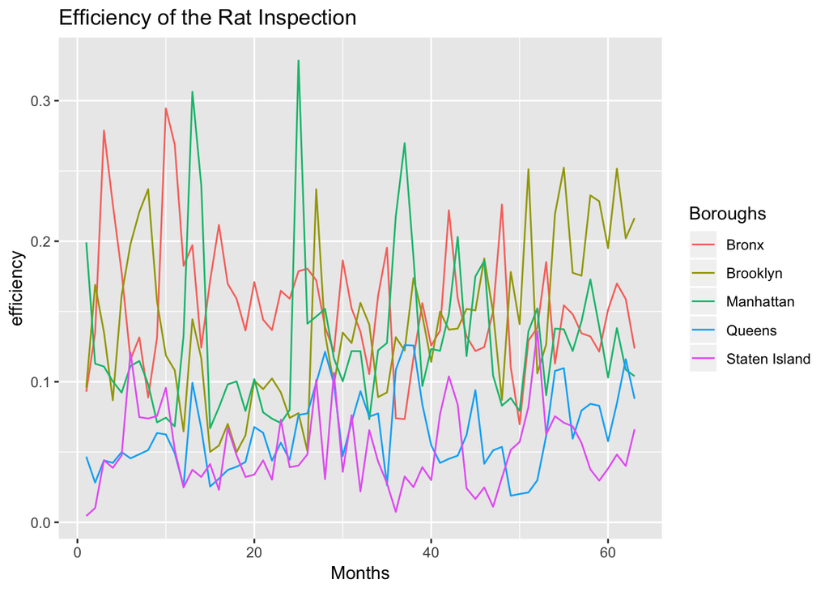

```r
ins_result_act <- rod.inspection %>% group_by(Month_sequence, BOROUGH) %>% filter(Year > 2010, RESULT == "Active Rat Signs") %>% tally()
ins_result_total <- rod.inspection %>% group_by(Month_sequence, BOROUGH) %>% filter(Year > 2010) %>% tally()
ins_result <- merge(ins_result_act, ins_result_total, by = c("Month_sequence", "BOROUGH"))
names(ins_result) <- c("Months", "Boroughs", "Active Signs", "Total Signs")

ins_result$efficiency <- ins_result$`Active Signs`/ins_result$`Total Signs`

ggplot(ins_result, aes(x = Months, y = efficiency, col = Boroughs)) + geom_line() + labs(title = "Efficiency of the Rat Inspection")
```

```r
rod.zip <- rod.inspection %>% group_by(Month_sequence, BOROUGH, ZIP_CODE) %>% filter(Year > 2010, RESULT == "Active Rat Signs") %>% tally()

# order the dataframe from the biggest value of active signs to the least and select the top 10
rod.zip <- rod.zip[order(-rod.zip$n),]
rod.zip <- rod.zip[c(1:10),]

top_10_zip <- list(rod.zip$ZIP_CODE)
```

# Part II. The 311 data

### a. Did Rodent Sightings Increase after Sandy?

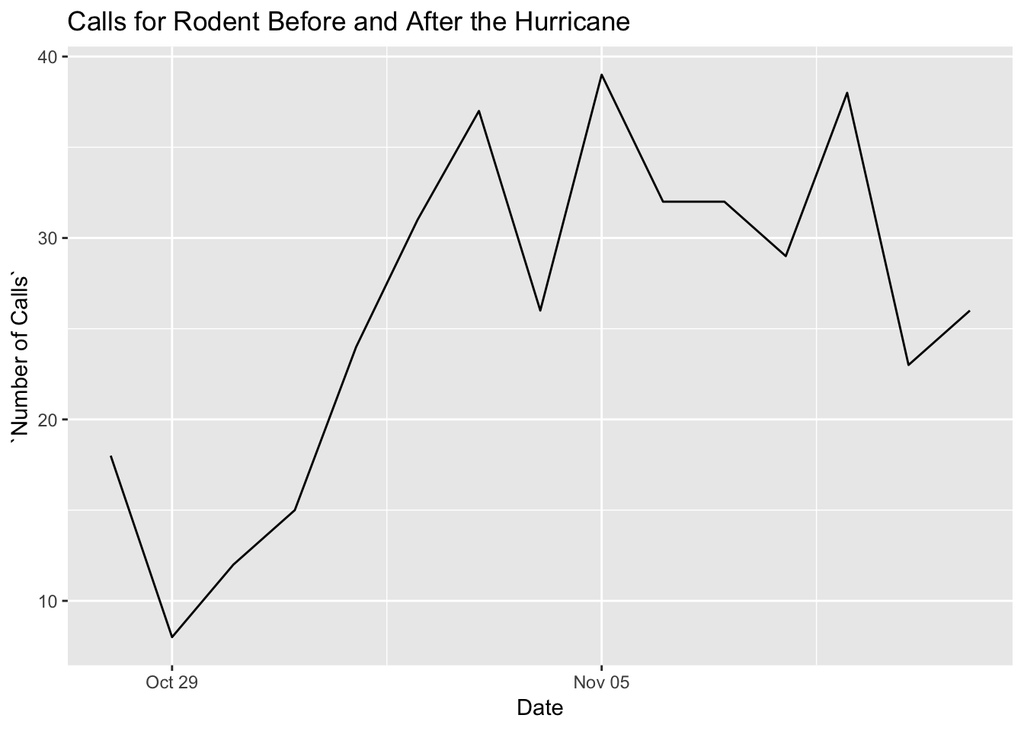

```r
Sandy.rod <- read_csv("/users/charlie/downloads/HW1/sandyrelated.csv")

Sandy.rod$newdate <- mdy_hm(Sandy.rod$`Created Date`)
Sandy.rod$date <- date(Sandy.rod$newdate)


rod.callin <- Sandy.rod %>% group_by(date) %>% filter(`Complaint Type` == "Rodent") %>% tally()
names(rod.callin) <- c("Date", "Number of Calls")

ggplot(rod.callin, aes(x = Date, y = `Number of Calls`)) + geom_line() + labs(title = "Calls for Rodent Before and After the Hurricane")
```

From the graph created above, the data does suggest that Hurricane Sandy led to an increase in the daily numbers of rodent sightings.

### b.Rodent Predictors

```r
complaint_type <- Sandy.rod %>% group_by(`Complaint Type`) %>% tally()
complaint_type <- complaint_type[order(-complaint_type$n),]
complaint_type <- complaint_type[c(1:15),]
rodent_num <- Sandy.rod %>% group_by(`Complaint Type`) %>% filter(`Complaint Type` == "Rodent") %>% tally()
complaint_type <- rbind(complaint_type,rodent_num)

# Create a dataframe that combines complaint_type and Sandy.rod, joining them with top 15 complaint types
sum_rod <- merge(complaint_type, Sandy.rod)

final_table <- select(sum_rod, `Complaint Type`, `Incident Zip`) %>% group_by(`Complaint Type`, `Incident Zip`) %>% tally() %>% spread(`Complaint Type`, n)
final_table[is.na(final_table)] <- 0
correlation <- cor(final_table)
# Showing the first three rows of the correlation
head(correlation, 3)
```

```
##                    Incident Zip Blocked Driveway Consumer Complaint
## Incident Zip         1.00000000      -0.07910476        -0.08637513
## Blocked Driveway    -0.07910476       1.00000000         0.45409037
## Consumer Complaint  -0.08637513       0.45409037         1.00000000
##                    Damaged Tree    ELECTRIC GENERAL CONSTRUCTION
## Incident Zip         -0.0849905 -0.06046603          -0.08856821
## Blocked Driveway      0.4152617  0.15306761           0.24117035
## Consumer Complaint    0.2514145  0.07072571           0.10563617
##                    General Construction/Plumbing    HEATING    NONCONST
## Incident Zip                          -0.1676957 -0.1046585 -0.08860683
## Blocked Driveway                       0.2239034  0.2410355  0.33150134
## Consumer Complaint                     0.3416883  0.1040982  0.16349910
##                    PAINT - PLASTER    PLUMBING      Rodent       Sewer
## Incident Zip           -0.08090993 -0.08996853 -0.09979007 -0.04780714
## Blocked Driveway        0.24705081  0.21919820  0.20969805  0.21594185
## Consumer Complaint      0.05846892  0.06133294  0.10448663  0.23894964
##                    Street Condition Street Light Condition
## Incident Zip             -0.1346326           -0.106213361
## Blocked Driveway          0.3212443           -0.005614293
## Consumer Complaint        0.3185582            0.228319656
##                    Traffic Signal Condition Water System
## Incident Zip                    -0.10569284  -0.07148986
## Blocked Driveway                -0.01879279   0.03093262
## Consumer Complaint               0.22844701   0.08169486
```

# Part III. Rodent and Restaurant Inspection

```r
res_inspection <- read_csv("/users/charlie/downloads/HW1/DOHMH_New_York_City_Restaurant_Inspection_Results.csv")

res_inspection$res_month <- month(mdy(res_inspection$`INSPECTION DATE`))
res_inspection$res_year <- year(mdy(res_inspection$`INSPECTION DATE`))

# Step 1. Get the Logged Values
rod_violation <- res_inspection %>% group_by(res_month, res_year, ZIPCODE) %>% filter((`VIOLATION CODE` == "04L") |`VIOLATION CODE` == "04K" | `VIOLATION CODE` == "08A") %>% tally()
names(rod_violation) <- c("month", "year", "zip code", "number of violations")
rod_violation$log <- log(rod_violation$`number of violations` + 1)

# Step 2. Join Rodent Inspection and New Data Set Together
rod_ins <- data.frame(rod.inspection$RESULT, rod.inspection$Month, rod.inspection$Year, rod.inspection$ZIP_CODE)
names(rod_ins) <- c("Result", "month", "year", "zip codes")

joint_ins <- merge(rod_ins, rod_violation, by.x = c("month", "year", "zip codes"), by.y = c("month", "year", "zip code"))

# Step 3. Active Rat Signs or Not
joint_ins$activity <- ifelse(joint_ins$Result == "Active Rat Signs", 1, 0)

# Step 4. Calculate the Logistic Regression
ActiveRatSigns <- glm(data = joint_ins, activity ~ log + as.factor(month) + as.factor(year), family = binomial)
summary(ActiveRatSigns)
```

```
##
## Call:
## glm(formula = activity ~ log + as.factor(month) + as.factor(year),
##     family = binomial, data = joint_ins)
##
## Deviance Residuals:
##     Min       1Q   Median       3Q      Max
## -0.6505  -0.5300  -0.5066  -0.4709   2.2418
##
## Coefficients:
##                      Estimate Std. Error z value Pr(>|z|)
## (Intercept)         -1.598104   0.089524 -17.851  < 2e-16 ***
## log                  0.070727   0.006603  10.712  < 2e-16 ***
## as.factor(month)2   -0.182162   0.024838  -7.334 2.24e-13 ***
## as.factor(month)3    0.014048   0.023372   0.601  0.54781
## as.factor(month)4   -0.071190   0.024361  -2.922  0.00347 **
## as.factor(month)5   -0.056070   0.024469  -2.292  0.02193 *
## as.factor(month)6    0.069370   0.025387   2.733  0.00629 **
## as.factor(month)7    0.074945   0.024681   3.037  0.00239 **
## as.factor(month)8    0.055023   0.024922   2.208  0.02726 *
## as.factor(month)9   -0.060561   0.025209  -2.402  0.01629 *
## as.factor(month)10   0.033780   0.024776   1.363  0.17275
## as.factor(month)11  -0.040460   0.026558  -1.523  0.12764
## as.factor(month)12  -0.141757   0.026251  -5.400 6.66e-08 ***
## as.factor(year)2012 -0.696953   0.087924  -7.927 2.25e-15 ***
## as.factor(year)2013 -0.488953   0.087956  -5.559 2.71e-08 ***
## as.factor(year)2014 -0.532234   0.088000  -6.048 1.47e-09 ***
## as.factor(year)2015 -0.460734   0.088065  -5.232 1.68e-07 ***
## as.factor(year)2016 -0.290961   0.090420  -3.218  0.00129 **
## ---
## Signif. codes:  0 '***' 0.001 '**' 0.01 '*' 0.05 '.' 0.1 ' ' 1
##
## (Dispersion parameter for binomial family taken to be 1)
##
##     Null deviance: 313363  on 421755  degrees of freedom
## Residual deviance: 312430  on 421738  degrees of freedom
##   (1 observation deleted due to missingness)
## AIC: 312466
##
## Number of Fisher Scoring iterations: 4
```

According to the output, there is a significant relationship between the restaurant inspection based measures and whether a rodent inspection yields Active Rat Signs. The p value for this relationship is much smaller than 0.05.

# Part IV Beyond Inspections

Air quality is somewhat related to pest problems. Bad air quality usually leads to severe pest problems. I would like to know if there really is a relation between New York’s rat problems and its air quality.

I would collect my data from this website:https://catalog.data.gov/dataset/air-quality-ef520. In the file I downloaded, I see among the data, there are boroughs, years of the survey, and the air quality. I think I can use the data to compare with the one in New York Rodent Inspection data sets.

To support my analysis, I would use graphs and regression to show the relation between the number of rodent problems and the number of bad air quality reports over the years.